# Exploration in Salary Requirements and Employee Attrition

Michael (Branum) Stephan

11/25/2019

```r
library(tidyverse)
library(cowplot)
library(corrplot)
library(ggthemes)
library(caret)
library(skimr)
library(reshape2)
library(dplyr)
library(stringr)
library(plotly)
library(fastDummies)
library(ggpubr)

# defining a global theme for all visualizations
cust_adj <- theme(legend.position="top", plot.title = element_text(hjust = 0.5),
  plot.subtitle = element_text(hjust = 0.5),
  plot.caption = element_text(hjust = 0.5, face="italic"))
theme_set(theme_classic() + cust_adj)
```

# About the Analysis

The dataset is comprised of various employee information along with whether or not the employee quit (attrition = “yes”). In order to ensure the algorithms can properly process the data, I’m setting text-based (categorical) data as factors and the numerical values as numeric decimals. Additionally, I’m reading in ordinal data as ordered factors with the assumption that various attributes like Environment Satisfaction aren’t continuous.

```r
# read in file to dataframe
root_dir <- '/Users/michaelstephan/Desktop/SMU/Doing Data Science/Final Project/'
attrition_data <- paste(root_dir,'resources/CaseStudy2-data.csv', sep="")
data <- data.frame(read.csv(attrition_data))

# remove "unnecessary" columns and save to eda dataframe
drop_cols <- c("ID", "EmployeeCount", "EmployeeNumber", "Over18", "StandardHours")
eda_df <- data %>% select(-one_of(drop_cols))

# ensure categorical data are factors
cat_cols <- c("Attrition", "BusinessTravel", "Department", "Education", "EducationField", "EnvironmentSatisfaction", "Gender", "JobInvolvement", "JobLevel",
              "JobRole", "JobSatisfaction", "MaritalStatus", "OverTime", "PerformanceRating", "RelationshipSatisfaction", "StockOptionLevel", "WorkLifeBalance")

# ensure all proper datatypes are met
eda_df <- eda_df %>% mutate_each_(funs(factor), cat_cols) %>% mutate_each(funs(as.numeric), -cat_cols)
```

# Part 1: Initial Exploratory Data Analysis

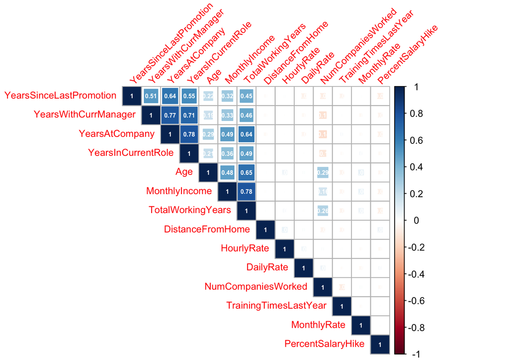

Figure 1: Numeric Correlation Plot

```r
# check numeric correlations
correlator  <-  function(df){
  df %>%
    keep(is.numeric) %>%
    tidyr::drop_na() %>%
    cor %>%
    corrplot("upper", addCoef.col = "white", number.digits = 2,
             number.cex = 0.5, method="square",
             order="hclust",
             tl.srt=45, tl.cex = 0.8)
}

# return correlation matrix of numerical values
correlator(eda_df)
```

In order to provide some insight to the relationship between the numerical data and Attrition, I have density plots below, colored by Attrition value. Among some of the features that are different between the Attrition and non-attrition employees the largest difference apperas to be from Monthly Income. There are some other differences seen between Age, Total Working Years, and Years at Company. However, as evident in the correlation plot above, these numerical features share some collinearity. Due to the most signficant difference in Monthly Income, it appears that that is one of the main factors for employee attrition.

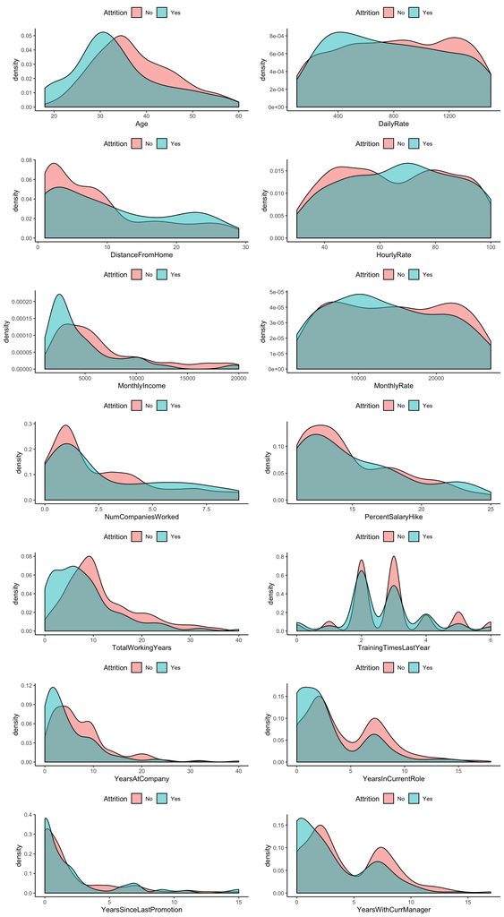

Figure 2: Numeric Features vs. Attrition

```r
# explore numeric vs. categorical (attrition) trends
# to help identify suitable numerical parameters
target <- "Attrition"
numvars <- eda_df %>% keep(is.numeric) %>% colnames

numplot <- function(df, explan, resp) {
  ggplot(data = df) + geom_density(aes_string(x = explan, fill = resp), alpha = 0.5)
}

plotlist <- lapply(numvars, function(x) numplot(eda_df, x, target))
plot_grid(plotlist=plotlist, ncol = 2, axis = "tblr", align=c("hv"))
```

In order to find similarities between the factoral data and the Attrition values, I’ve created some bar charts to show the relative percentage of attrition among each category. Some of the notable qualities of those who quit are Job Involvement, Job Level, Job Role (high salesman attrition), Work Life Balance, and Overtime Status. The most significant values are Overtime, Worklife Balance, and Job Involvement. Job Role suggests that salesman are the most common role to leave.Research director and manufacturing director are among the rarest to leave, which may be due to having a higher income in their management roles (evidence has already suggested the influence of income on attrition).

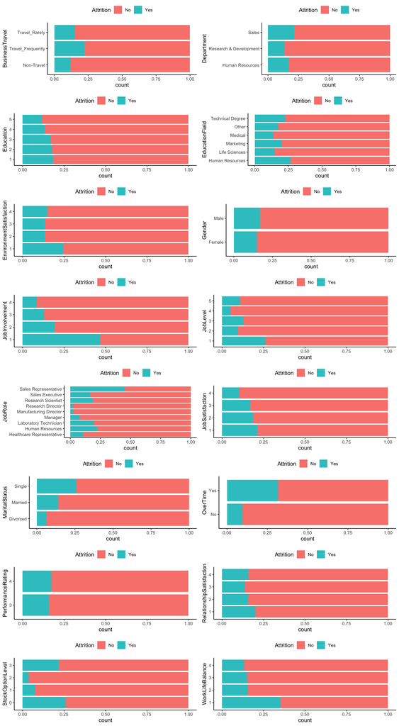

Figure 3: Factoral features vs. Attrition

```r
# explore categorical vs. categorical data
target <- "Attrition"

# step 2: name explanatory vars

expls <- eda_df[, !(names(eda_df) %in% c(target))] %>% keep(is.factor) %>% colnames


catplot <- function(df, x,y){
  ggplot(data = df, aes_string(x = x, fill = y)) +
    geom_bar(position = "fill", alpha = 0.9) +
    coord_flip()
}


plotlist2 <- lapply(expls, function(x) catplot(eda_df, x, target))

# findings: JobRole - High amount of Sales Reps, JobInvolvement, Overtime, WorkLifeBalance
plot_grid(plotlist=plotlist2, ncol=2)
```

Because overtime and monthly income are both income/financial related, it may prove beneficial to create an “interaction” between them. First, I’ll make a factoral variable based on binning different quantiles of income among those employees who quit. Then, I’ll create a new concatenation of income level and overtime status. You can see below that although initially binning the income class has shown a very convincing argument that income class is related to attrition, the incorporation with overtime accounts shows a class comprised of almost 75% attritions! I believe this to be a really good single indicator of employee attrition.

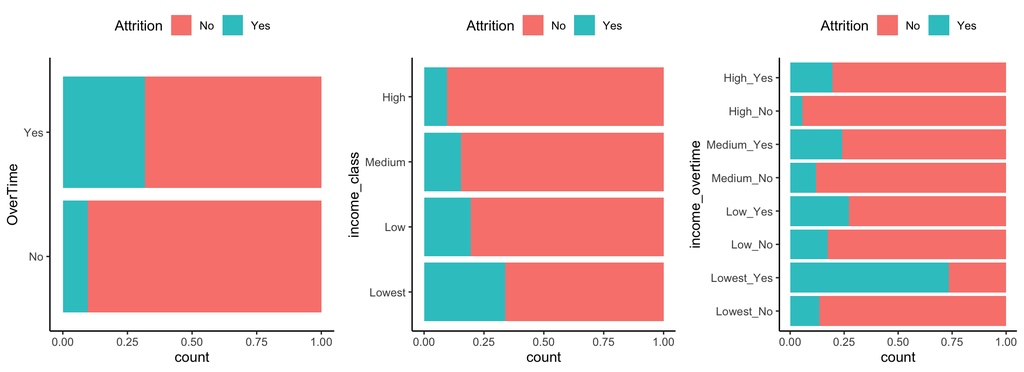

Figure 4: Custom Features vs. Attrition

```r
# income class
b <- c(-Inf, 2500, 3000, 5000, Inf)
names <- c("Lowest", "Low", "Medium", "High")
eda_df$income_class = factor(cut(eda_df$MonthlyIncome, breaks = b, labels = names), order=TRUE, levels=c("Lowest", "Low", "Medium", "High"))

# income class with overtime
eda_df$income_overtime = factor(paste(eda_df$income_class, eda_df$OverTime, sep="_"), order=TRUE, levels=c("Lowest_No", "Lowest_Yes", 'Low_No','Low_Yes', 'Medium_No', 'Medium_Yes','High_No', 'High_Yes'))

# plot new created features
plotlist3 <- lapply(c("OverTime", "income_class", "income_overtime"), function(x) catplot(eda_df, x, target))

# findings: JobRole - High amount of Sales Reps, JobInvolvement, Overtime, WorkLifeBalance
plot_grid(plotlist=plotlist3, ncol=3)
```

# Part 2: Predicting Employee Attrition

Based on the evidence above, I’m going to proceed to a comparison of KNN and Naive Bayes models based on Work Life Balance, Income-Overtime, and Job Involvement.

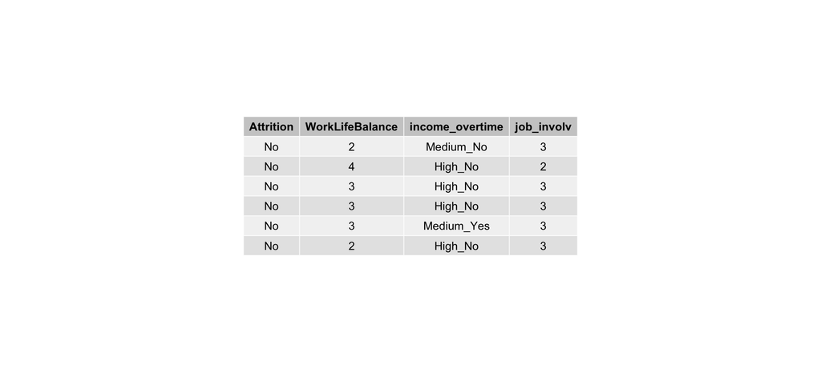

Figure 5: Major Attrition Features

```r
# create matrix of results and scale numeric values
eda_df2 <- eda_df %>% mutate(job_involv = factor(JobInvolvement, order = TRUE, levels=c(1,2,3,4)),
                             WorkLifeBalance = factor(WorkLifeBalance, order = TRUE, levels=c(1,2,3,4))) %>% mutate_if(is.numeric, scale) %>% select(Attrition, WorkLifeBalance, income_overtime, job_involv)
ggtexttable(head(eda_df2), rows=NULL)
```

Now that I have a good grasp on the most influencial features, it’s time to test model performance against the benchmark criteria. To get the best representation possible, I’ve created a permutation loop to perform 100 different random train-test-split permutations. In order to get the best comparison between model methods (KNN vs. Naive Bayes), I’m performing a model analysis on both models for each iterations. In all, there will be 200 different measurements, which I’ll then analyze to determine the best model to proceed.

```r
# main loop for benchmarking model performance
model_check <- function(df, target, k, model_types=c("knn", "nb"), row_progress=TRUE){
m = matrix(nrow = k*length(model_types), ncol = 5)
x=1  # row counter
# loop through each run
for(i in 1:k){

  # create a random permutation of train-test split
  indxTrain <- createDataPartition(y = df[,target],p = 0.70,list = FALSE)
  training_df <- df[indxTrain,]
  testing_df <- df[-indxTrain,]

  # build predictive model based on new permutation
  for (model_type in model_types){
    if(row_progress == TRUE){
    print(sprintf("Run Number: %s Model Type: %s X-value: %s", i, model_type, x))
    }
    model <- train(as.formula(paste(target, "~ .")), data = training_df, metric = "spec", method = model_type)
    # make predictions based on model
    Predict <- predict(model, newdata=testing_df[, !(names(testing_df) %in% c(target))])

    # assign test statistics to a matrix
    results = confusionMatrix(table(testing_df[,target], Predict))
    m[x, 1] = i
    m[x, 2] = model_type
    m[x, 3] = results$overall[1]
    m[x, 4] = results$byClass[1]
    m[x, 5] = results$byClass[2]
      x = x + 1
  }
  }
  colnames(m) = c("run_number", "model_type", "Accuracy", "Sensitivity", "Specificity")
  m <- as.data.frame(m)
  return(m)
}

# run model for 100 loops
k=100
evaluate <- model_check(eda_df2, "Attrition", k, row_progress = FALSE)
```

In order to perform some comparison between the models, I ensure that accuracy, sensitivity, and specificity are numeric values. Additionally, I add a metric to test the occurrence of a value below of 0.6 benchmark.

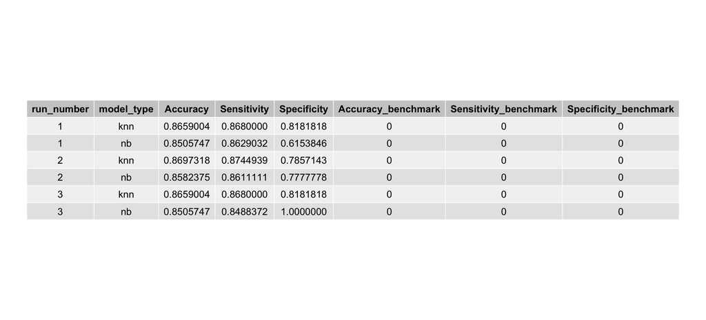

Figure 6: Sample of Accuracy Benchmark

```r
# adding benchmark criteria and ensuring datatypes are met
evaluate$Accuracy <- as.numeric(as.character(evaluate$Accuracy))
evaluate$Sensitivity <- as.numeric(as.character(evaluate$Sensitivity))
evaluate$Specificity <- as.numeric(as.character(evaluate$Specificity))

evaluate$Accuracy_benchmark <- ifelse(evaluate$Accuracy < 0.6, 1, 0)
evaluate$Sensitivity_benchmark <- ifelse(evaluate$Sensitivity < 0.6, 1, 0)
evaluate$Specificity_benchmark <- ifelse(evaluate$Specificity < 0.6, 1, 0)
ggtexttable(head(evaluate), rows=NULL)
```

In order to get better insight, I restructure the output to provide both a summary and visual analysis of both models.

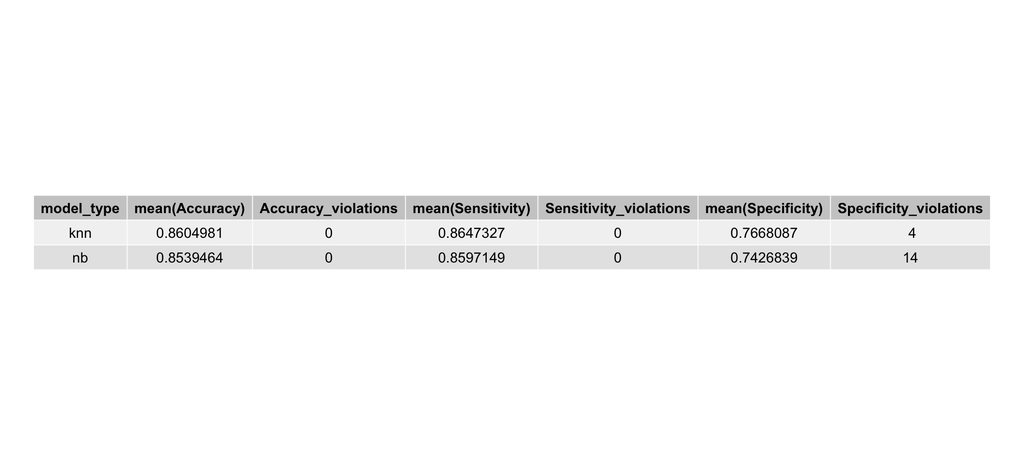

Figure 7: Summary of Benchmarks by Model Type

```r
summary_df <- evaluate %>% group_by(model_type) %>% summarise(mean(Accuracy), Accuracy_violations=sum(Accuracy_benchmark), mean(Sensitivity), Sensitivity_violations=sum(Sensitivity_benchmark), mean(Specificity), Specificity_violations=sum(Specificity_benchmark))

ggtexttable(head(summary_df), rows=NULL)
```

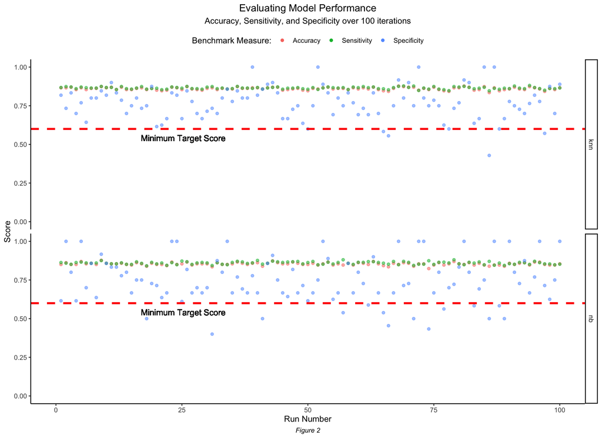

Figure 8: Graphical Analysis of Benchmark by Model Type

```r
# restructure for plot
results_melt <- melt(evaluate, id.vars=c("run_number", "model_type"), measure.vars=c("Accuracy", "Sensitivity","Specificity"))
# plot accuracy, sensivity, specificity for each run
results_melt %>% ggplot(aes(x=as.numeric(run_number), y=as.numeric(value))) + geom_point(aes(color = variable, alpha=0.5)) + facet_grid(rows = vars(model_type)) +
  geom_hline(yintercept=0.6, linetype="dashed", color="red", size=1.25) + geom_text(aes(0,0.6,label = "Minimum Target Score", hjust=-1, vjust = 2)) +
  ylim(0,1) + labs(title="Evaluating Model Performance",subtitle = "Accuracy, Sensitivity, and Specificity over 100 iterations",caption="Figure 2", x = "Run Number", y="Score", color="Benchmark Measure:") + guides(alpha=FALSE)
```

# Part 3: Modeling Employee Pay

Based on the correlation plot, there is extremly strong evidence that Total Working Years (experience) is the largest factor in Monthly Income among employees in the dataset. Additional exploration shows that Job Level, and Management Status also provide additional support.

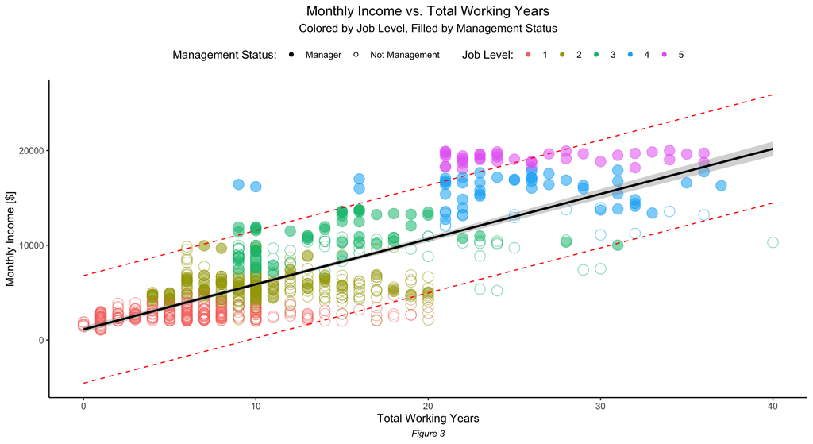

Figure 9: Regression Parameters vs. Monthly Income

```r
# find regression line based on most strongly correlated parameter - total working years
# create a basic linear regression model for Monthly Income and Total Working Years
experience_model <- lm(MonthlyIncome ~ TotalWorkingYears, data=eda_df)
salary_plot <- cbind(eda_df, predict(experience_model, interval="prediction")) %>%
  mutate(management = case_when(str_detect(JobRole, "Manager") | str_detect(JobRole, "Director") ~ "Manager", TRUE ~"Not Management")) %>%
  ggplot(aes(x=TotalWorkingYears, y=MonthlyIncome)) +
  geom_point(aes(color=JobLevel, shape=management, size=0.6, alpha=0.95)) +
  scale_shape_manual(values = c(19, 1)) + geom_smooth(method="lm", color='black') +
  geom_line(aes(y=lwr), color = "red", linetype = "dashed")+
  geom_line(aes(y=upr), color = "red", linetype = "dashed")+
  labs(title="Monthly Income vs. Total Working Years",subtitle = "Colored by Job Level, Filled by Management Status",caption="Figure 3", x = "Total Working Years", y="Monthly Income [$]", color="Job Level:", shape="Management Status:") + theme(legend.position="top")+guides(size=FALSE, alpha=FALSE)

salary_plot
```

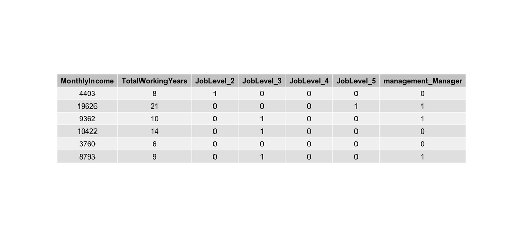

Figure 10: Sample of Regression Training Set

```r
# create dataframe from conclusion in the plotted model
income_df <- eda_df %>% mutate(management = case_when(str_detect(JobRole, "Manager") | str_detect(JobRole, "Director") ~ "Manager", TRUE ~"Not Management")) %>% dummy_cols(select_columns=c("JobLevel", "management"), remove_first_dummy = TRUE) %>% select(MonthlyIncome,  TotalWorkingYears, JobLevel_2, JobLevel_3, JobLevel_4, JobLevel_5, management_Manager)

ggtexttable(head(income_df), rows=NULL)
```

```r
# create regression model to predict salary based on model
salary_model = train(MonthlyIncome~., data = income_df, method = "lm")
summary(salary_model)
```

```
##
## Call:
## lm(formula = .outcome ~ ., data = dat)
##
## Residuals:
##     Min      1Q  Median      3Q     Max
## -4491.9  -646.6  -113.4   660.4  4692.6
##
## Coefficients:
##                    Estimate Std. Error t value Pr(>|t|)
## (Intercept)         2522.87      84.45  29.874  < 2e-16 ***
## TotalWorkingYears     37.15       8.94   4.155 3.58e-05 ***
## JobLevel_2          2415.69     104.76  23.059  < 2e-16 ***
## JobLevel_3          6287.51     154.32  40.743  < 2e-16 ***
## JobLevel_4         10811.09     263.18  41.079  < 2e-16 ***
## JobLevel_5         14453.59     306.33  47.184  < 2e-16 ***
## management_Manager  1271.69     127.76   9.954  < 2e-16 ***
## ---
## Signif. codes:  0 '***' 0.001 '**' 0.01 '*' 0.05 '.' 0.1 ' ' 1
##
## Residual standard error: 1190 on 863 degrees of freedom
## Multiple R-squared:  0.9335, Adjusted R-squared:  0.933
## F-statistic:  2018 on 6 and 863 DF,  p-value: < 2.2e-16
```

# Conclusion

### Attrition Prediction Model

According to the a combination of “trial and error”, along with correlation and density analysis, I was able to create a KNN model boasting an average accuracy of 0.86, average specificity of 0.77, and an average sensitivity of 0.86 on 100 random permutations.Based on the features chosen in the model, it appears that **the three most influencial characterisitics of an employee who quits are a monthly income less than 2500 with overtime status, poor work life balance, and low work involvement.**

### Salary Prediction Model

The features that contribute to most significantly to the prediction of the monthly income of an employee can most be credited to total experience (total working years), job level, and management status. Due to factoral features, these have been “dummy coded” to produce the following multiple regression model:

#### Model:

Salary = (2522.87 + 37.14 * (Total Working Years)) + (2415.68 * (Job Level 2 [Y/N])) + (6287.50 * (Job Level 3 [Y/N])) + (10811.08 * (Job Level 4 [Y/N])) + (14453.59 * (Job Level 5 [Y/N])) + (1271.69 * (Management Status [Y/N]))

#### Analysis:

Assuming all factors as zero, the minimum monthly income is $2522.87. For every increase in one year of experience, there is an increase of $37.14 in monthly income. All else held constant, an increase from job level 1 to job level 2 results in a $2415.68 increase in monthly income. An increase from job level 1 to 3 results in an increase of $6287.50 in monthly income. An increase from job level 1 to 4 results in an increase of $10811.08 monthly income. Lastly, an increase from job level 1 to level 5 results in an increase of $14453.59 in monthly income. Within each job level, having a “manager” or “director” title adds an additional $1271.69 in monthly income in comparison to non-management, all else held constant.

### Additional Findings

1. Of all the job roles in the dataset, almost 50% of salesman had quit their job, suggesting there may be an internal issue at play. In contrast, those in management and director positions had the lowest attrition rates, which perhaps complements their typically higher monthly income.
2. Of all marital statuses in teh dataset, it appears that divorcees have the highest non-attrition rates, suggesting an interesting possibility of work life balance issues at this particular company? Is it possible that the additional stress from work is causing issues at home?
3. A large portion of the non-attrition employees live within 10-15 miles of the office. In contrast, those who quit have a more balance distribution of distance from the office. Is it possible that daily commutes are playing a role in employee attrition?